# シカゴ研修旅行 2016

浅野ゼミでは、2016年4月6日～11日の間、政経学部の学部生と院生の計5名がシカゴ研修旅行に参加しました。研修目的はアメリカ中西部政治学会 (MPSA: Midwestern Political Science Association) のカンファレンスに参加することと異文化学習です。参加者は自主的な計画を立てて、シカゴを満喫してきました。

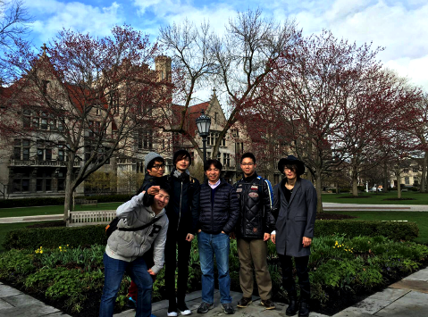

シカゴ大学にて

#### 4月6日

成田国際空港から搭乗し、14時間後にシカゴオヘア空港に到着しました。空港に到着後、MPSA会場であるPalmer House Hilton Hotelに向かい、その後チェックインまで時間があったため、ホテル近くのパンダエクスプレスでランチをとり、ダウンタウン周辺を散策しました。シカゴの街には意匠を凝らした建物や街並みが多く、その素晴らしさに圧倒されました。また、アメリカ大統領選に出馬していることで有名なトランプ氏が所有するトランプタワーを見学しました。

[figure not shown]

#### 4月7日

朝食では、ヒルトンホテルのブラックファスト・ビッフェを体験しました。朝食後、バスに乗って学部生はシカゴ大学に行きました。シカゴ大学では、早稲田大学から留学している日本人学生の半田さんに大学構内の教室や図書館内などを案内していただきました。構内には、歴史を感じさせる建造物が並び、荘重な雰囲気に包まれていました。 夜には、立教大学からウィスコンシン大学に長期留学されている村瀬先生とボール州立大学で政治学を教えている西川先生と夕食を共にすることができ、巨大なシカゴピザを食べながら貴重なお話を伺いました。その後、地上103階、約412mもの高さのあるSkydeckから、シカゴの街の夜景を一望しました。夜景の美しさに驚嘆しました。Skydeckには全面ガラス張りのバルコニーがあり、下に落ちるのではないかとひやひやしながらシカゴの夜景を満喫しました。

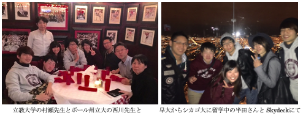

#### 4月8日

午前から午後にかけ科学博物館に行きました。シカゴの科学博物館は、自然現象を人工的に作り、それを肌で体感できる一種のアミューズメント・パークのようなとても充実した施設でした。夕食では、アメリカで人気のMichael Jordan’s The Steakhouseに行きました。少々値が張りましたが、 十分その金額に見合うだけの美味しさでした。

#### 4月9日

この日は、ゼミの指導教授である浅野先生とテキサス工科大学のパターソン教授によるMPSAカンファレンスでの論文発表を聴講しました。5,000名を超える研究者たちが世界中から集うカンファレンスで発表される論文の内容はとても難しかったのですが、政治学における最先端の様々な研究に触れることができ、大変貴重な時間を過ごすことができました。夕食では、日本の首都大学東京や国際大学からMPSAカンファレンスに参加されている先生方と一緒にシカゴのチャイナタウンへと地下鉄で赴き、北京ダックやチャイニーズ・ブロッコリーなど本格的な中華料理を満喫しました。

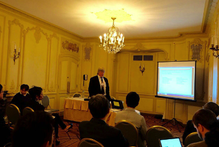

MPSAカンファレンスで発表中のパターソン先生と浅野先生

#### 4月10日

ホテル周辺のカフェでの朝食後、12時35分発のJAL便に搭乗し、成田国際空港へと発ちました。後ろ髪を引かれる思いで、シカゴを後にし、私たちのアメリカ研修を無事終えることができました。

4泊5日という短期間ではありましたが、シカゴという大都市に滞在し、異文化に触れることで様々な経験を得ることができました。それは、普段の大学生活で過ごす生活とは全く違い特別な体験でした。この貴重な体験をひとりひとりが今後の大学生活やゼミの活動、そして人生に活かしたいと思います。

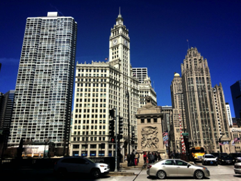

シカゴのダウンタウンの風景

（文責：経済学科三年 田辺征拓）